# TP_tree

```python
import numpy as np
import matplotlib.pyplot as plt
from sklearn import tree
from sklearn import tree, datasets
import pandas as pd
import numpy as np
from sklearn.model_selection import GridSearchCV
from tp_arbres_source import (rand_gauss, rand_bi_gauss, rand_tri_gauss,
                              rand_checkers, rand_clown, plot_2d,
                              frontiere,frontiere_new)
from sklearn.model_selection import learning_curve
from sklearn.model_selection import ShuffleSplit
from sklearn.model_selection import cross_val_score
from sklearn.model_selection import train_test_split
from sklearn import linear_model
from sklearn.linear_model import LogisticRegression
import seaborn as sns
from matplotlib import rc
from sklearn.tree import DecisionTreeClassifier
%matplotlib inline
plt.close('all')
rc('font', **{'family': 'sans-serif', 'sans-serif': ['Computer Modern Roman']})
params = {'axes.labelsize': 12,
          'font.size': 16,
          'legend.fontsize': 16,
          'text.usetex': False,
          'figure.figsize': (8, 6)}
plt.rcParams.update(params)

sns.set_context("poster")
sns.set_palette("colorblind")
sns.set_style("white")
_ = sns.axes_style()
```

## Arbres de décision - Algorithme CART

#### 1) Dans le cadre de la régression (i.e.,quand on cherche à prédire une valeur numérique pour Y et non une classe), proposez une autre mesure d'homogénéité. Justifier votre choix.

On peut choisir la variance comme mesure d'homogénéité.

2)Simulez avec rand_checkers des échantillons de taille n = 456 (attention à bien équilibrer les classes). Créez deux courbes qui donnent le pourcentage d'erreurs commises en fonction de la profondeur maximale de l'arbre (une courbe pour Gini, une courbe pour l'entropie). On laissera les autres paramètres à leur valeurs par défaut.

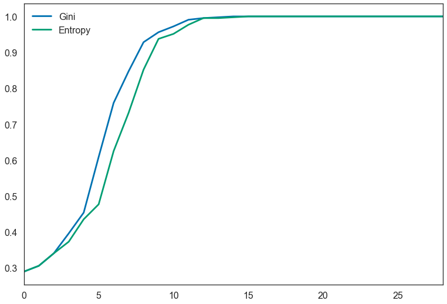

```python
rg_checkers_train = rand_checkers(n1=111, n2=111,n3=112,n4=112, sigma=0.1)

X = rg_checkers_train[:,0:2]
y = rg_checkers_train[:,2]

score_Gini = []
score_Entropy =[]

max_depth = 30

for i in range(1,max_depth):
    clf = DecisionTreeClassifier(random_state=0,criterion = 'gini' ,max_depth = i)
    clf.fit(X,y)
    score_Gini.append(clf.score(X, y))

for i in range(1,max_depth):
    clf = DecisionTreeClassifier(random_state=0,criterion = 'entropy' ,max_depth = i)
    clf.fit(X,y)
    score_Entropy.append(clf.score(X, y))

score = pd.DataFrame(score_Gini , columns=['Gini'])
score['Entropy'] = score_Entropy
score.plot()
```

#### 3)Afficher la classification obtenue en utilisant la profondeur qui minimise le pourcentage d'erreurs obtenues avec l'entropie (utiliser si besoin les fonctionsplot_2d et frontiere du fichier source).

```python
entropy_depth = np.argmax(score_Entropy)
```

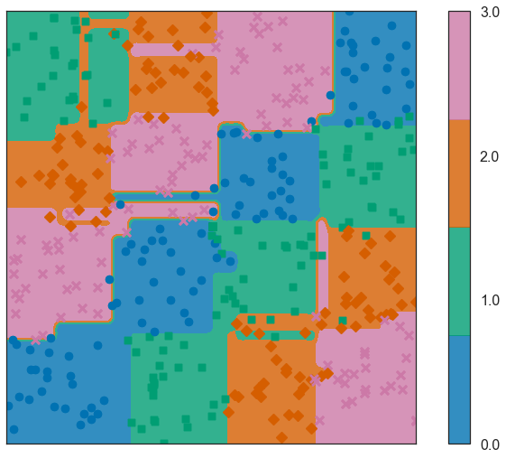

```python
clf = DecisionTreeClassifier(random_state=0,criterion = 'entropy' ,max_depth = entropy_depth)
def f(xx):
    return clf.predict(xx.reshape(1, -1))
clf.fit(X, y)
plt.figure()
plot_2d(X, y)
n_labels = np.unique(y).shape[0]
frontiere_new(f, X, y, w=None, step=50, alpha_choice=1, colorbar=True,samples=True)
```

#### 4) Exporter un graphique de l'arbre obtenu à la question précédente en format pdf. On pourra par exemple utiliser la fonction export_graphviz du module tree.

```python
tree.export_graphviz(clf,out_file='tree.dot')
```

#### 5)Créez n = 160 = 40 + 40 + 40 + 40 nouvelles données avec rand_checkers. Pour les arbres de décision obtenus en question 2, calculer la proportion d'erreurs faites sur cet échantillon de test. Commenter.

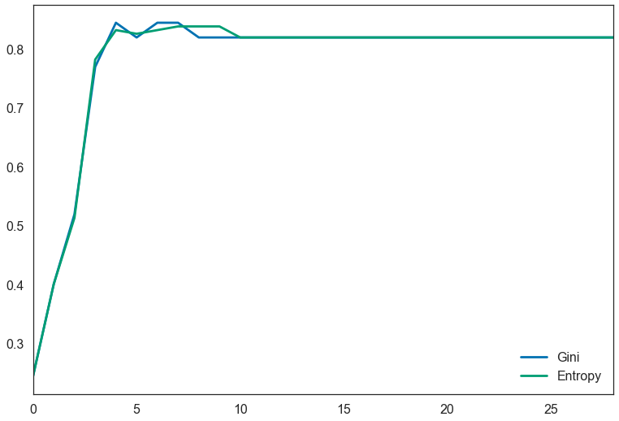

```python
rg_checkers_test = rand_checkers(n1=40, n2=40,n3=40,n4=40, sigma=0.1)

X_test = rg_checkers_test[:,0:2]
y_test = rg_checkers_test[:,2]

score_Gini = []
score_Entropy =[]

max_depth = 30

for i in range(1,max_depth):
    clf = DecisionTreeClassifier(random_state=0,criterion = 'gini' ,max_depth = i)
    clf.fit(X,y)
    score_Gini.append(clf.score(X_test, y_test))

for i in range(1,max_depth):
    clf = DecisionTreeClassifier(random_state=0,criterion = 'entropy' ,max_depth = i)
    clf.fit(X,y)
    score_Entropy.append(clf.score(X_test, y_test))

score = pd.DataFrame(score_Gini , columns=['Gini'])
score['Entropy'] = score_Entropy
score.plot()
```

#### 6) Reprendre la question 2 pour le datasetzipcode. Ce jeu de données est disponible dans le modulesklearn.datasets

```python
digits = datasets.load_digits()
```

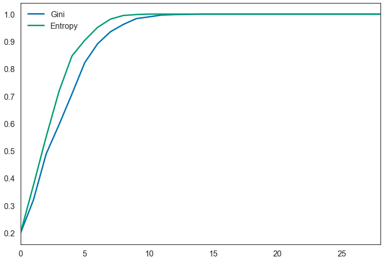

```python
X = digits['data']
y = digits['target']

score_Gini = []
score_Entropy =[]

max_depth = 30

for i in range(1,max_depth):
    clf = DecisionTreeClassifier(random_state=0,criterion = 'gini' ,max_depth = i)
    clf.fit(X,y)
    score_Gini.append(clf.score(X, y))

for i in range(1,max_depth):
    clf = DecisionTreeClassifier(random_state=0,criterion = 'entropy' ,max_depth = i)
    clf.fit(X,y)
    score_Entropy.append(clf.score(X, y))

score = pd.DataFrame(score_Gini , columns=['Gini'])
score['Entropy'] = score_Entropy
score.plot()
```

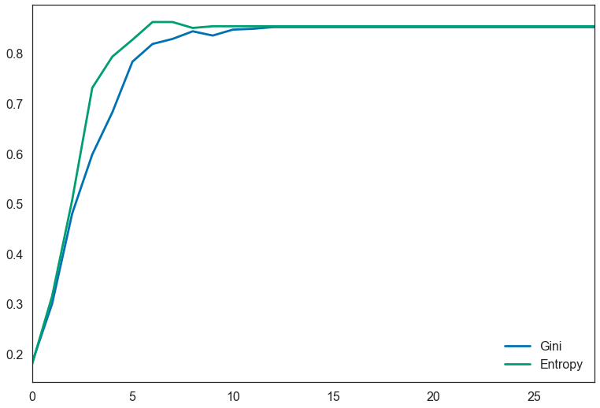

```python
X = digits['data']
y = digits['target']
X_train, X_test, y_train, y_test = train_test_split(X, y, test_size=0.33, random_state=42)

score_Gini = []
score_Entropy =[]

max_depth = 30

for i in range(1,max_depth):
    clf = DecisionTreeClassifier(random_state=0,criterion = 'gini' ,max_depth = i)
    clf.fit(X_train,y_train)
    score_Gini.append(clf.score(X_test, y_test))

for i in range(1,max_depth):
    clf = DecisionTreeClassifier(random_state=0,criterion = 'entropy' ,max_depth = i)
    clf.fit(X_train,y_train)
    score_Entropy.append(clf.score(X_test, y_test))

score = pd.DataFrame(score_Gini , columns=['Gini'])
score['Entropy'] = score_Entropy
score.plot()
```

#### 7) Utiliser la fonction sklearn.cross_validation.cross_val_scoreet tester la sur le jeu de données zipcode en faisant varier la profondeur de l'arbre de décision. On pourra se servir de cette fonction pour choisir la profondeur de l'arbre.

```python
dt = DecisionTreeClassifier(random_state=0)
parameters = {'criterion':('gini', 'entropy'), 'max_depth': range(1,50)}
clf = GridSearchCV(dt, parameters)
clf.fit(X,y)
print(clf.best_params_)
print(clf.best_score_)
```

```
{'criterion': 'entropy', 'max_depth': 11}
0.794657762938
```

#### 8) En s'inspirant de http://scikit-learn.org/stable/auto_examples/model_selection/plot_learning_curve.html afficher la courbe d'apprentissage (en :learning curve) pour les arbres de décisions sur le même jeu de données1.

```python
def plot_learning_curve(estimator, title, X, y, ylim=None, cv=None,\
                        n_jobs=1, train_sizes=np.linspace(.1, 1.0, 5)):
    plt.figure()
    plt.title(title)
    if ylim is not None:
        plt.ylim(*ylim)
    plt.xlabel("Training examples")
    plt.ylabel("Score")
    train_sizes, train_scores, test_scores = learning_curve(
        estimator, X, y, cv=cv, n_jobs=n_jobs, train_sizes=train_sizes)
    train_scores_mean = np.mean(train_scores, axis=1)
    train_scores_std = np.std(train_scores, axis=1)
    test_scores_mean = np.mean(test_scores, axis=1)
    test_scores_std = np.std(test_scores, axis=1)
    plt.grid()

    plt.fill_between(train_sizes, train_scores_mean - train_scores_std,
                     train_scores_mean + train_scores_std, alpha=0.1,
                     color="r")
    plt.fill_between(train_sizes, test_scores_mean - test_scores_std,
                     test_scores_mean + test_scores_std, alpha=0.1, color="g")
    plt.plot(train_sizes, train_scores_mean, 'o-', color="r",
             label="Training score")
    plt.plot(train_sizes, test_scores_mean, 'o-', color="g",
             label="Cross-validation score")

    plt.legend(loc="best")
    return plt
```

```
<module 'matplotlib.pyplot' from '/Users/auredt7892/anaconda/lib/python3.6/site-packages/matplotlib/pyplot.py'>
```

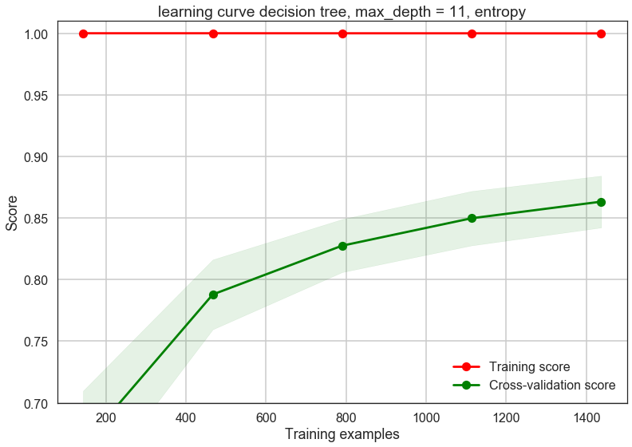

```python
dt = DecisionTreeClassifier(random_state=0, max_depth=11, criterion='entropy')
title='learning curve decision tree, max_depth = 11, entropy'

cv = ShuffleSplit(n_splits=100, test_size=0.2, random_state=0)

plot_learning_curve(dt, title, X, y, ylim=(0.7, 1.01), cv=cv, n_jobs=2)
```

## Régression logistique

#### 9) Reprendre le jeu de données obtenu par rand_checkers. Effectuer une régression logistique sur ce jeu de données et donner la proportion d'erreur commise en apprentissage. Comparer la performance par rapport à la méthode par arbre de décision. Commenter

```python
logreg = LogisticRegression(random_state =0,fit_intercept = False)
logreg.fit(X,y)

print(logreg.score(X,y))
```

```
0.344907407407
```

#### 12) Proposer trois manières d'appliquer la classi cation par régression logistique aux données issues de la basezipcode. Détailler votre démarche. Testez-en deux, par exemple en utilisant des courbes d'apprentissage comme ci-dessus.

```
<module 'matplotlib.pyplot' from '/Users/auredt7892/anaconda/lib/python3.6/site-packages/matplotlib/pyplot.py'>
```

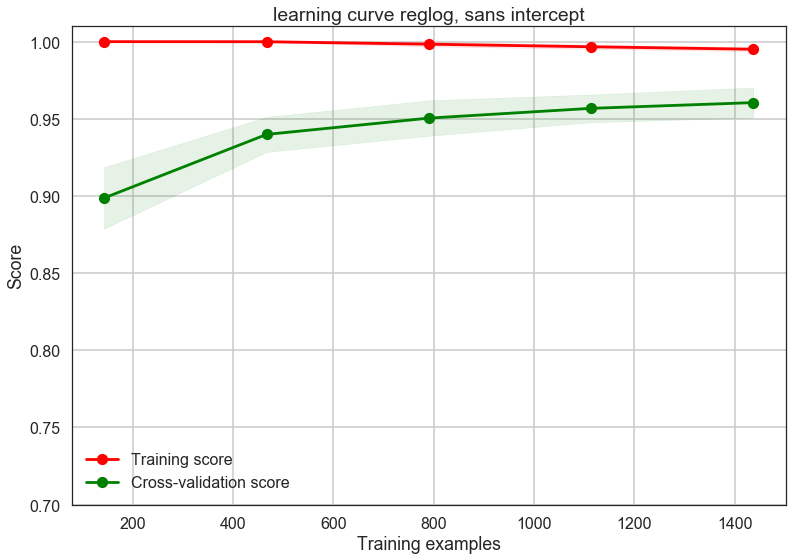

```python
X = digits['data']
y = digits['target']
X_train, X_test, y_train, y_test = train_test_split(X, y, test_size=0.33, random_state=42)

cv = ShuffleSplit(n_splits=50, test_size=0.2, random_state=0)
title='learning curve reglog, sans intercept'
plot_learning_curve(logreg, title, X, y, ylim=(0.7, 1.01), cv=cv, n_jobs=2)
```